# Worked Example: Arthritis

Johan Larsson

## Arthritis

In this worked example we will be working with data from a treatment trial for Arthritis. The data comes from the [vcd package](https://CRAN.R-project.org/package=vcd). To begin, let’s load the package and take a `glimpse()` at the data.

```r
# install.packages("vcd") # if you haven't installed it yet
library(vcd)
library(tidyverse)

glimpse(Arthritis)
```

```
## Rows: 84
## Columns: 5
## $ ID        <int> 57, 46, 77, 17, 36, 23, 75, 39, 33, 55, 30, 5, 63, 83, 66, 4…
## $ Treatment <fct> Treated, Treated, Treated, Treated, Treated, Treated, Treate…
## $ Sex       <fct> Male, Male, Male, Male, Male, Male, Male, Male, Male, Male, …
## $ Age       <int> 27, 29, 30, 32, 46, 58, 59, 59, 63, 63, 64, 64, 69, 70, 23, …
## $ Improved  <ord> Some, None, None, Marked, Marked, Marked, None, Marked, None…
```

Notice that `Improved` is helpfully formatted as an ordinal (ordered) variable already, which is going to help ggplot to choose the correct color palettes for us.

## Bar Charts

Let’s start with a simple bar chart to see how many people were allocated to the two treatment arms.

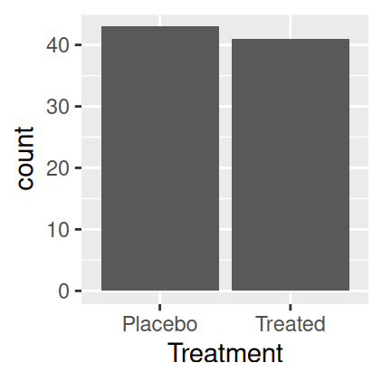

Treatment allocation for the arthritis study.

```r
library(tidyverse)

ggplot(Arthritis, aes(Treatment)) +
  geom_bar()
```

### Was the Treatment Effective?

Now for something more interesting. Let’s try to look at how well the treatment seems to have worked. We start with a stacked bar chart.

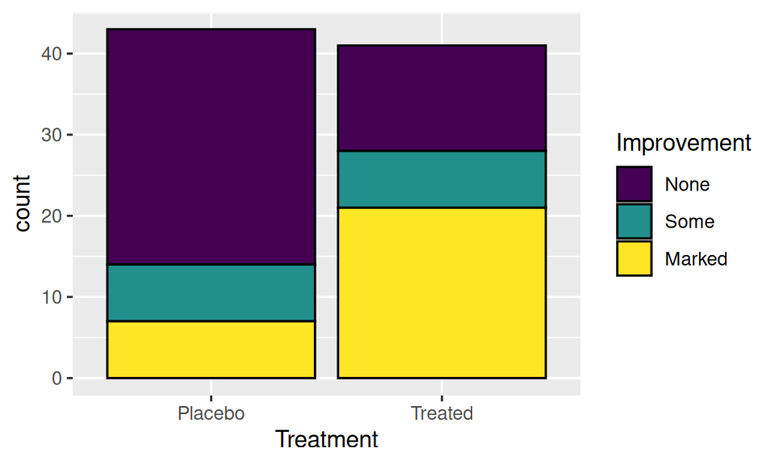

Treatment effect in the arthritis study.

```r
ggplot(Arthritis, aes(Treatment, fill = Improved)) +
  geom_bar(color = "black") +
  labs(fill = "Improvement") # add a better legend title
```

It’s immediately clear that the treatment has worked well! The count of people with a improvement is much higher in the treatment arm compared with the placebo arm. But how do the treatments compare when it comes to people who’ve made *some* improvement? This is difficult to say from our approach here. This is due to two reasons:

1. The stacked bar chart makes it hard to compare all but the first category, since the other portions of the bars are not aligned.[^1]
2. The bars are not proportional.[^2]

Let’s try a grouped proportional bar chart instead. To do this, we need to do a little preparatory work since there is no direct option to do this in ggplot2.

What we need to do is to prepare a data set with the proportions that we would like to plot. In the following lines, we

1. use `count()` to count the number of observations in each combination of `Treatment` and `Improved`,
2. group the data set by `Treatment`, and
3. compute the proportions using `mutate()`.

```r
arthritis_prop <-
  Arthritis %>%
  count(Treatment, Improved) %>% # like group_by + summarize
  group_by(Treatment) %>%
  mutate(prop = n / sum(n))
```

Now we’re ready to construct our plot, which we do exactly like a standard grouped bar plot, except we use `geom_col()` and map the `y` aesthetic since we have summary data.

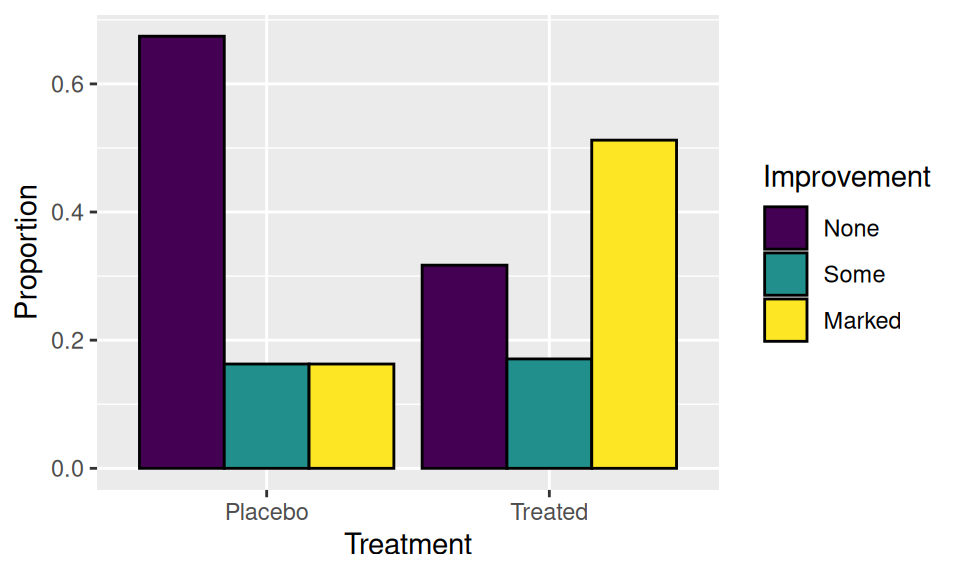

Grouped, proportional bar chart of the arthritis data.

```r
ggplot(arthritis_prop, aes(Treatment, prop, fill = Improved)) +
  geom_col(color = "black", position = "dodge") +
  labs(fill = "Improvement", y = "Proportion")
```

No it’s suddenly quite easy to compare the proportion of people who improved some between the two groups.

See if you can create a proportional stacked bar chart too and compare the result with your previous charts.

## Mosaic Plots

In the lecture we also encountered mosaic plots, which are proportional bar charts that map not only the height of the bars but also the width of the bars to group sizes. We’ll use the **ggmosaic** package here.

```r
# install.packages("ggmosaic") # if don't already have the package

library(ggmosaic)
```

**ggmosaic** works directly with a ggplot2 object, adding auxiliary functions (`geom_*()` functions) to extend its functionality.

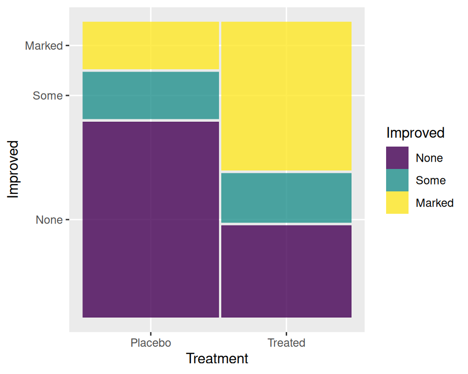

```r
ggplot(Arthritis) +
  geom_mosaic(aes(x = product(Improved, Treatment), fill = Improved))
```

The key features to notice about this call are

1. that the `aes()` specification must reside *inside* the call to `geom_mosaic()`, and not in the `ggplot()` function and
2. the call to `product()`, which acts simply as a list of variables that you want to use in the mosaic plot.

The main benefit of the mosaic plot is that we get to see more of the data. With the bar charts we needed to separate visualizations to provide information on the overall size of the groups (treatment arms), whereas with the mosaic plot we can make do with only a single plot.[^3]

Try to switch the order of the variables in the `product()` call. What happens? How has the information you see changed?

## Waffle Plots

Waffle plots are easy-to-read visualizations that are actually quite uncommon in statistical visualizations but much more prevalent in media outlets such as newspapers. They are, as we mentioned in the lecture, at their best when some of the categories are so small that their sizes are hard to estimate in a bar chart or mosaic plot.

For that reason, waffle plots are not compulsory material in this course and will instead serve as bonus material for those who are interested.

To download development versions of R packages from GitHub, you need the remotes package or the devtools package.

```r
# install remotes
install.packages("remotes")

# install waffle
remotes::install_github("hrbrmstr/waffle") # or devtools::install_github()
```

The waffle package requires that our data contains counts of the categories, so before we can use it, we need to do a bit of wrangling. More precisely, you need to group the data by `Improved` and `Treatment` and then use `summarize()` together with either the `n()` function to get either counts or some other expression for proportions. We’ll settle for counts in this example. Before looking at the following code, see if you can do this by yourself. The result should be a 6-row tibble with columns `Treatment`, `Improved` and `Count` (or whatever you want to call it). Save the result to an object called `arthritis_summarized`.

```r
arthritis_summarized <-
  Arthritis %>%
  group_by(Treatment, Improved) %>%
  summarize(Count = n())
```

Now we’re ready to start making waffles! The aesthetics you need to know about here are `fill` and `values`. Values is what we want to map the counts or proportions that we just created to and `fill` will connect our inner-most group to fill color. We start with the simplest possible waffle chart, just looking at improvement among the participants in the treatment arm.

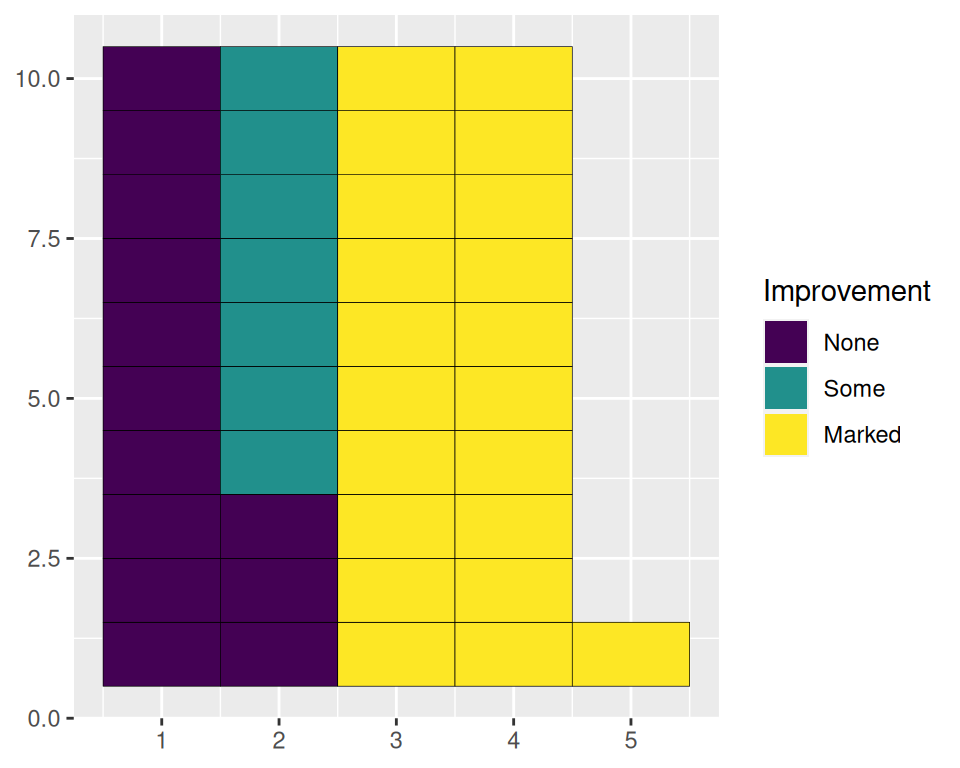

A basic waffle chart of the results from the treatment arm.

```r
library(waffle)

filter(arthritis_summarized, Treatment == "Treated") %>%
  ggplot(aes(fill = Improved, values = Count)) +
  geom_waffle() +
  labs(fill = "Improvement")
```

This looks kind of like a waffle chart, but there’s a lot of superfluous information that we’d rather get rid off. Thankfully, **waffle** provides the helpful `theme_enhance_waffle()` function for this. Moreover, we probably prefer the symbols (rectangles) to be squares—it’s supposed to look like a waffle after all, right?—which we can accomplish by forcing the coordinate system to be isometric using `coord_equal()`. Finally, I think it looks more aesthetically pleasing if we swap the black line color for white, increase their widths slightly, and change theme to the minimal variant.

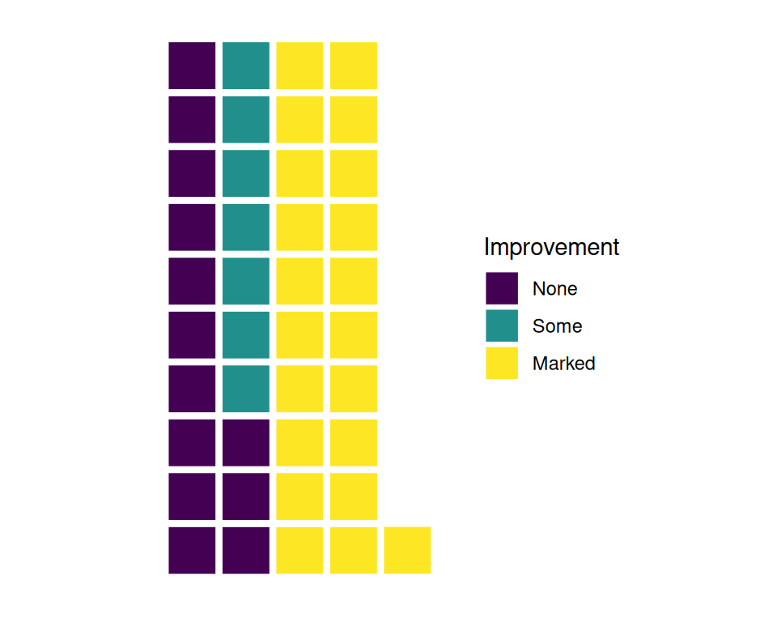

A prettier waffle plot.

```r
filter(arthritis_summarized, Treatment == "Treated") %>%
  ggplot(aes(fill = Improved, values = Count)) +
  geom_waffle(color = "white", size = 1.5) +
  coord_equal() +
  theme_minimal() +
  theme_enhance_waffle() +
  labs(fill = "Improvement")
```

That looks much better, doesn’t it?

To be able to use waffle charts to see both of the treatment arms at once, we need to use something called **facets**, which we haven’t covered in the course yet. If you already know about facets, however, feel free to modify the plot now by faceting on the type of treatment.

## Source Code

The source code for this document is available at https://github.com/stat-lu/dataviz/blob/main/worked-example-arthritis.Rmd.

[^1]: This is not quite as severe a problem for this particular visualization since the inner grouping variable is ordinal. For other problems, however, this can be much more detrimental to the result.
[^2]: To be fair, the differences between the group sizes are small here, but this also means that we don’t lose much information when using proportional bars instead.
[^3]: But note that it is the *relative* size that we show. If we want the actual *counts* in the outer category, we still need to add additional plots or provide this information in text.
[^4]: Feel free to voice your support for a CRAN update at https://github.com/hrbrmstr/waffle/issues/72.